# 3. Reporte descriptivo

Asistente de investigación: Valentina Andrade

última actualización: 16 octubre,2022

# 1 Admisión, postulación y selección

Para la siguiente figura se utilizaron los data sets de `puntajes_consolidado_v3` y los de los tres sistemas de postulación. Las categorías se construyeron a partir de la presencia o ausencia de *mrun* en algunos archivos, junto con las marcas resultantes de su proceso de admisión.

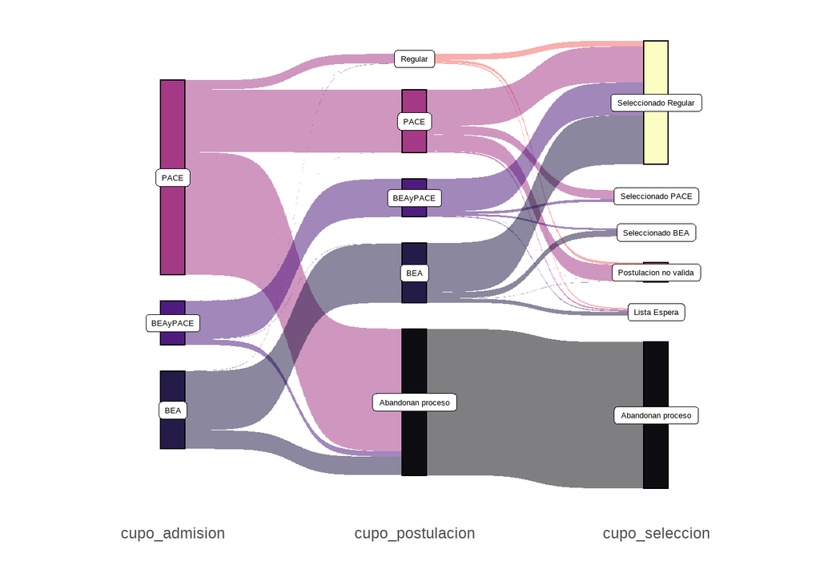

**Figura 1**

Como podemos notar hay un porcentaje importante de estudiantes que rinden las pruebas y/o recuperan puntaje que deciden desertar del proceso de admisión. De ellos, una parte importante proviene de PACE.

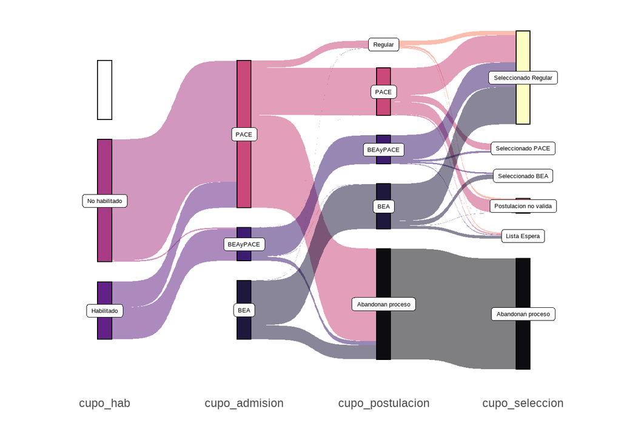

**Figura 2**

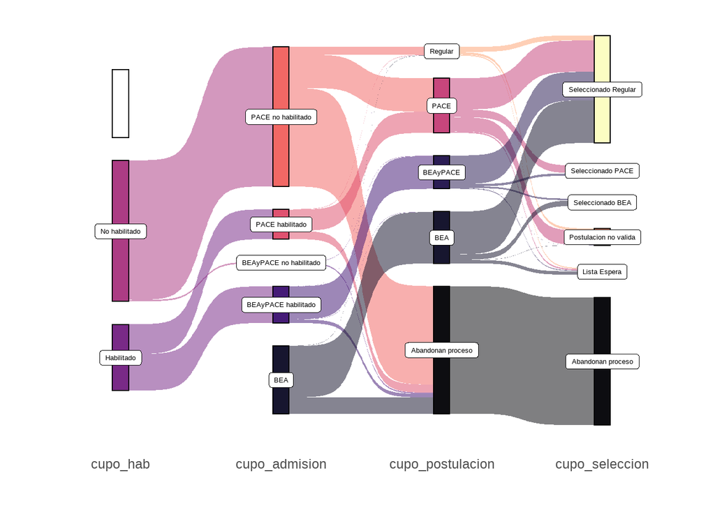

**Figura 3**

Tabla 1. Proporciones de flujo

| cupo_admision | cupo_postulacion | cupo_seleccion | n | per |
| --- | --- | --- | --- | --- |
| BEA | Abandonan proceso | Abandonan proceso | 2353 | 23.84 |
|  | BEA | Lista Espera | 492 | 4.98 |
|  |  | Postulacion no valida | 29 | 0.29 |
|  |  | Seleccionado BEA | 783 | 7.93 |
|  |  | Seleccionado Regular | 6176 | 62.57 |
|  | Regular | Lista Espera | 5 | 0.05 |
|  |  | Postulacion no valida | 1 | 0.01 |
|  |  | Seleccionado Regular | 32 | 0.32 |
| BEAyPACE habilitado | Abandonan proceso | Abandonan proceso | 511 | 9.57 |
|  | BEA | Lista Espera | 1 | 0.02 |
|  |  | Seleccionado BEA | 4 | 0.07 |
|  |  | Seleccionado Regular | 36 | 0.67 |
|  | BEAyPACE | Lista Espera | 101 | 1.89 |
|  |  | Postulacion no valida | 7 | 0.13 |
|  |  | Seleccionado BEA | 238 | 4.46 |
|  |  | Seleccionado PACE | 338 | 6.33 |
|  |  | Seleccionado Regular | 4094 | 76.71 |
|  | PACE | Lista Espera | 1 | 0.02 |
|  |  | Seleccionado PACE | 1 | 0.02 |
|  | Regular | Seleccionado Regular | 5 | 0.09 |
| BEAyPACE no habilitado | Abandonan proceso | Abandonan proceso | 169 | 76.82 |
|  | BEAyPACE | Postulacion no valida | 3 | 1.36 |
|  |  | Seleccionado BEA | 2 | 0.91 |
|  |  | Seleccionado Regular | 46 | 20.91 |
| PACE habilitado | Abandonan proceso | Abandonan proceso | 1186 | 27.42 |
|  | PACE | Lista Espera | 189 | 4.37 |
|  |  | Postulacion no valida | 1 | 0.02 |
|  |  | Seleccionado PACE | 1107 | 25.59 |
|  |  | Seleccionado Regular | 1786 | 41.29 |
|  | Regular | Lista Espera | 1 | 0.02 |
|  |  | Postulacion no valida | 8 | 0.18 |
|  |  | Seleccionado Regular | 48 | 1.11 |
| PACE no habilitado | Abandonan proceso | Abandonan proceso | 14335 | 70.58 |
|  | PACE | Postulacion no valida | 2086 | 10.27 |
|  |  | Seleccionado PACE | 2 | 0.01 |
|  |  | Seleccionado Regular | 2770 | 13.64 |
|  | Regular | Lista Espera | 149 | 0.73 |
|  |  | Postulacion no valida | 319 | 1.57 |
|  |  | Seleccionado Regular | 650 | 3.20 |

- Extrañamente hay dos MRUN de estudiantes PACE no habilitados (ambos no cumplen criterio 2) que aparecen con marca 24 en el file del proceso de postulación PACE (8176546 y 26462204) ambos en preferencia 3.

## 1.1 Selección en carreras más demandadas

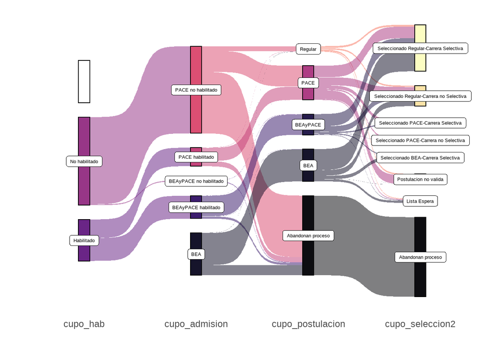

**Figura 4**

Tabla 2. Proporciones de flujo

| cupo_admision | cupo_postulacion | cupo_seleccion2 | n | per |
| --- | --- | --- | --- | --- |
| BEA | Abandonan proceso | Abandonan proceso | 2353 | 23.84 |
|  | BEA | Lista Espera | 492 | 4.98 |
|  |  | Postulacion no valida | 29 | 0.29 |
|  |  | Seleccionado BEA-Carrera Selectiva | 783 | 7.93 |
|  |  | Seleccionado Regular-Carrera no Selectiva | 1297 | 13.14 |
|  |  | Seleccionado Regular-Carrera Selectiva | 4879 | 49.43 |
|  | Regular | Lista Espera | 5 | 0.05 |
|  |  | Postulacion no valida | 1 | 0.01 |
|  |  | Seleccionado Regular-Carrera no Selectiva | 3 | 0.03 |
|  |  | Seleccionado Regular-Carrera Selectiva | 29 | 0.29 |
| BEAyPACE habilitado | Abandonan proceso | Abandonan proceso | 511 | 9.57 |
|  | BEA | Lista Espera | 1 | 0.02 |
|  |  | Seleccionado BEA-Carrera Selectiva | 4 | 0.07 |
|  |  | Seleccionado Regular-Carrera no Selectiva | 11 | 0.21 |
|  |  | Seleccionado Regular-Carrera Selectiva | 25 | 0.47 |
|  | BEAyPACE | Lista Espera | 101 | 1.89 |
|  |  | Postulacion no valida | 7 | 0.13 |
|  |  | Seleccionado BEA-Carrera Selectiva | 238 | 4.46 |
|  |  | Seleccionado PACE-Carrera no Selectiva | 48 | 0.90 |
|  |  | Seleccionado PACE-Carrera Selectiva | 290 | 5.43 |
|  |  | Seleccionado Regular-Carrera no Selectiva | 1292 | 24.21 |
|  |  | Seleccionado Regular-Carrera Selectiva | 2802 | 52.50 |
|  | PACE | Lista Espera | 1 | 0.02 |
|  |  | Seleccionado PACE-Carrera Selectiva | 1 | 0.02 |
|  | Regular | Seleccionado Regular-Carrera no Selectiva | 1 | 0.02 |
|  |  | Seleccionado Regular-Carrera Selectiva | 4 | 0.07 |
| BEAyPACE no habilitado | Abandonan proceso | Abandonan proceso | 169 | 76.82 |
|  | BEAyPACE | Postulacion no valida | 3 | 1.36 |
|  |  | Seleccionado BEA-Carrera Selectiva | 2 | 0.91 |
|  |  | Seleccionado Regular-Carrera no Selectiva | 14 | 6.36 |
|  |  | Seleccionado Regular-Carrera Selectiva | 32 | 14.55 |
| PACE habilitado | Abandonan proceso | Abandonan proceso | 1186 | 27.42 |
|  | PACE | Lista Espera | 189 | 4.37 |
|  |  | Postulacion no valida | 1 | 0.02 |
|  |  | Seleccionado PACE-Carrera no Selectiva | 316 | 7.30 |
|  |  | Seleccionado PACE-Carrera Selectiva | 791 | 18.28 |
|  |  | Seleccionado Regular-Carrera no Selectiva | 579 | 13.38 |
|  |  | Seleccionado Regular-Carrera Selectiva | 1207 | 27.90 |
|  | Regular | Lista Espera | 1 | 0.02 |
|  |  | Postulacion no valida | 8 | 0.18 |
|  |  | Seleccionado Regular-Carrera no Selectiva | 17 | 0.39 |
|  |  | Seleccionado Regular-Carrera Selectiva | 31 | 0.72 |
| PACE no habilitado | Abandonan proceso | Abandonan proceso | 14335 | 70.58 |
|  | PACE | Postulacion no valida | 2086 | 10.27 |
|  |  | Seleccionado PACE-Carrera Selectiva | 2 | 0.01 |
|  |  | Seleccionado Regular-Carrera no Selectiva | 1272 | 6.26 |
|  |  | Seleccionado Regular-Carrera Selectiva | 1498 | 7.38 |
|  | Regular | Lista Espera | 149 | 0.73 |
|  |  | Postulacion no valida | 319 | 1.57 |
|  |  | Seleccionado Regular-Carrera no Selectiva | 302 | 1.49 |
|  |  | Seleccionado Regular-Carrera Selectiva | 348 | 1.71 |

## 1.2 Sankeys desagregados

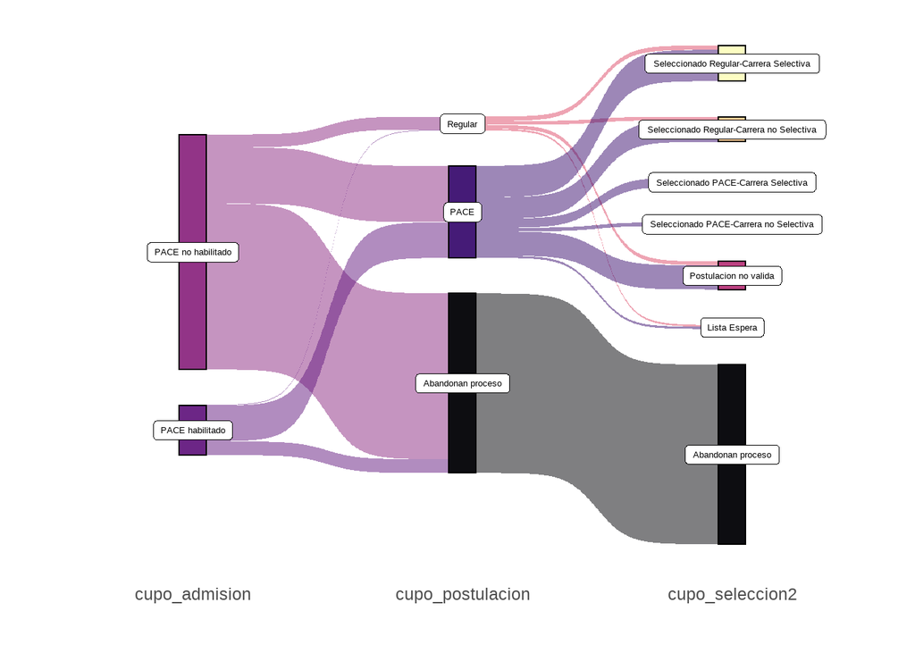

**Figura 5**. Flujo estudiantes PACE

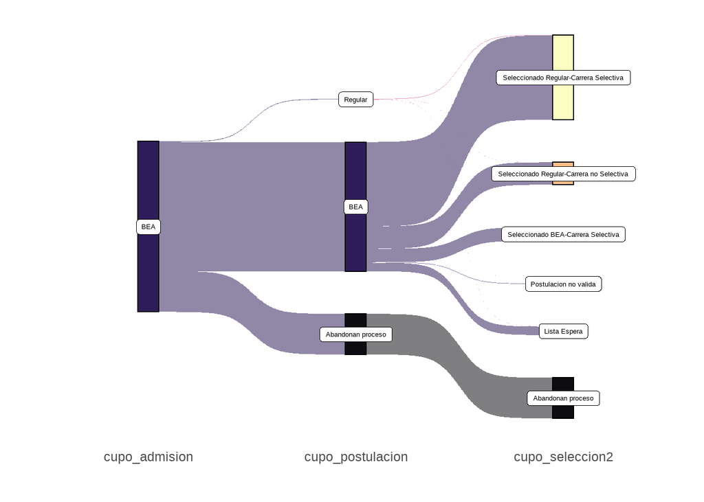

**Figura 6**. Flujo estudiantes BEA

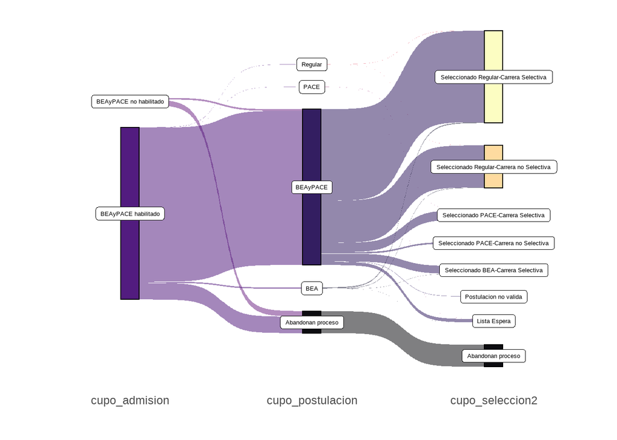

**Figura 7**. Flujo estudiantes BEA y PACE

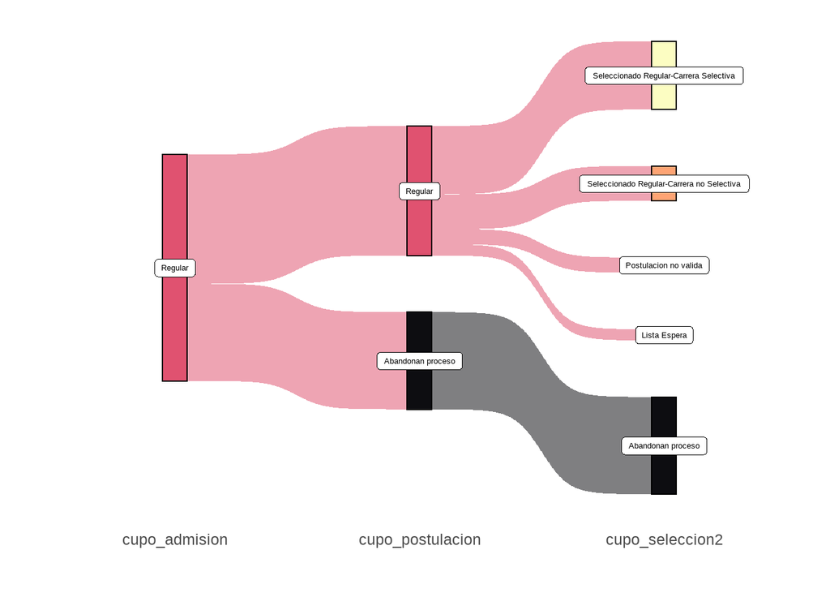

**Figura 8**. Flujo estudiantes admisión Regular

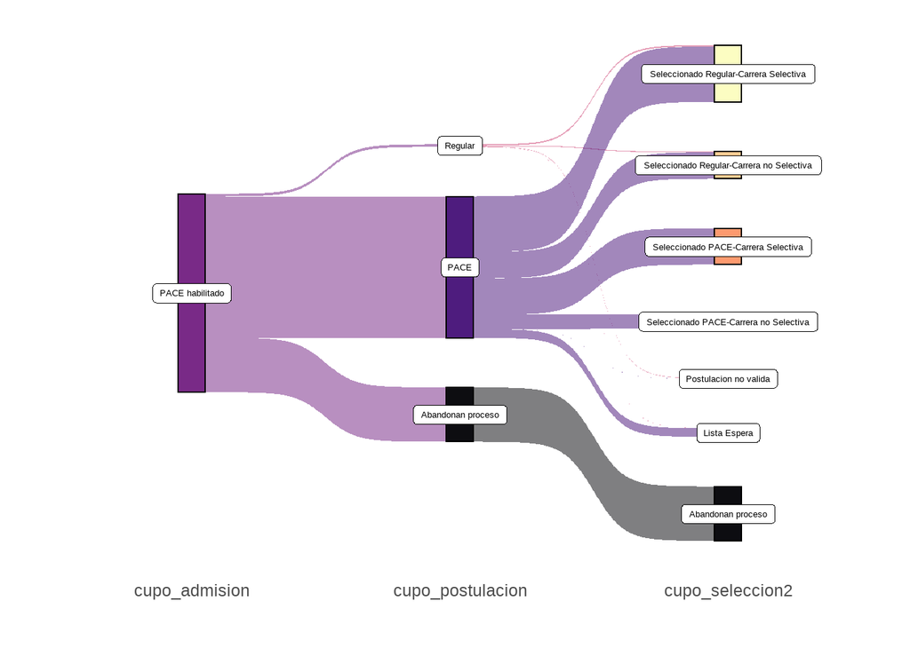

**Figura 9**. Flujo estudiantes admisión PACE habilitados

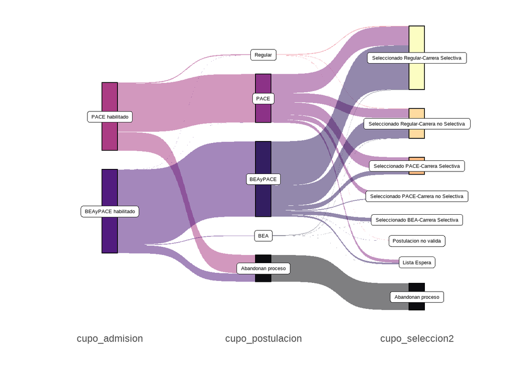

**Figura 10**. Flujo estudiantes admisión PACE habilitados (+ intersección BEA y PACE habilitados)

# 2 Oferta

# 3 Selectividad y utilización

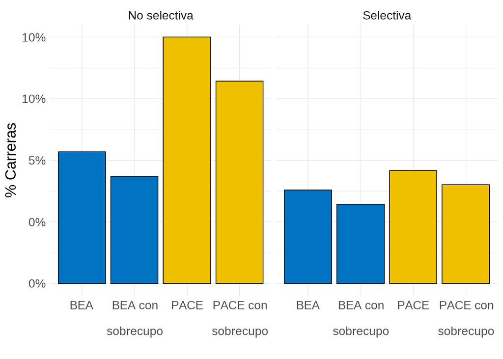

**Figura 11**

## 3.1 Figure 2 in report

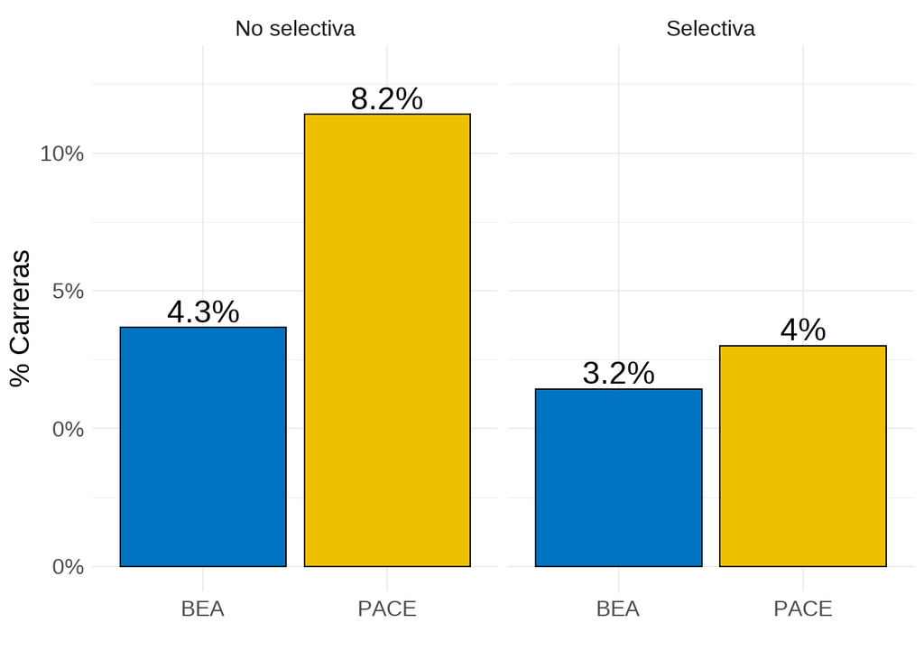

**Figura 12**. Sin cupos llenos

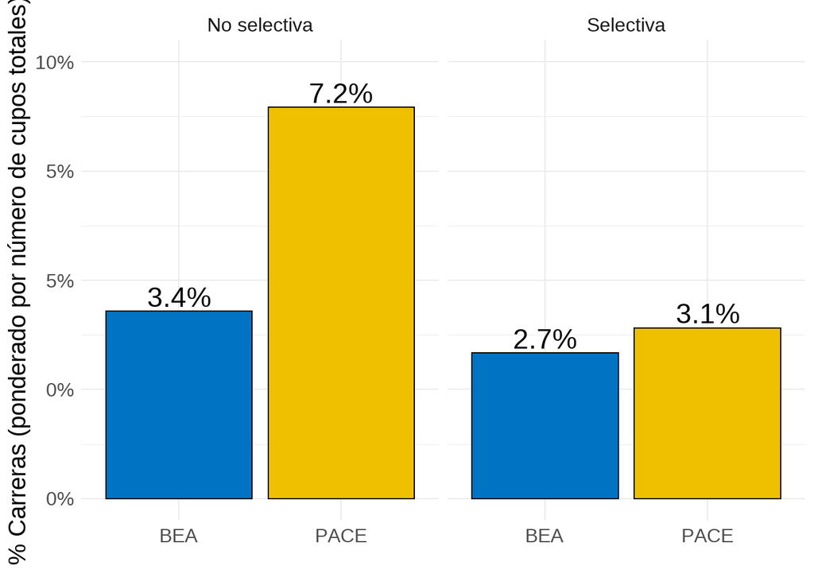

**Figura 13**

# 4 Agregado a nivel de cupos

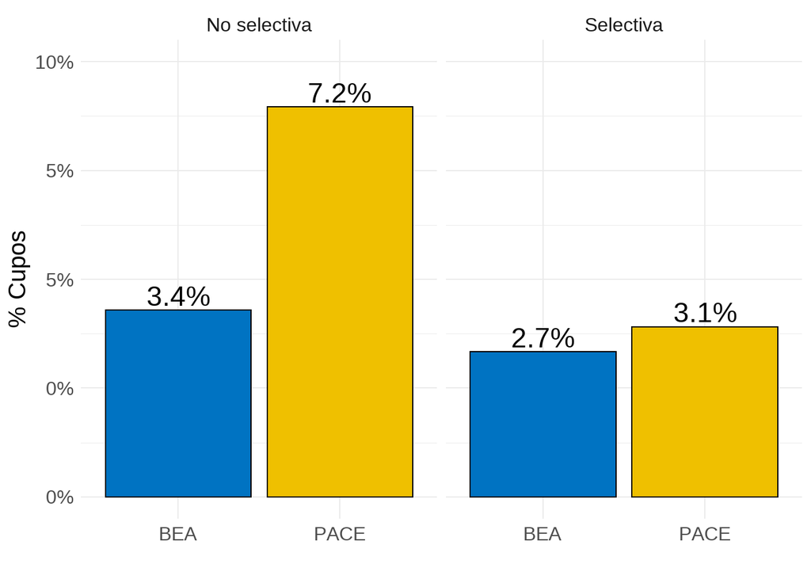

**Figura 14**. El % se calcula con $\frac{N°~cupos~completos ~BEA~}{N°~total~cupos~ofertados}$ (lo mismo respectivamente con PACE)

# 5 Utilización cupos

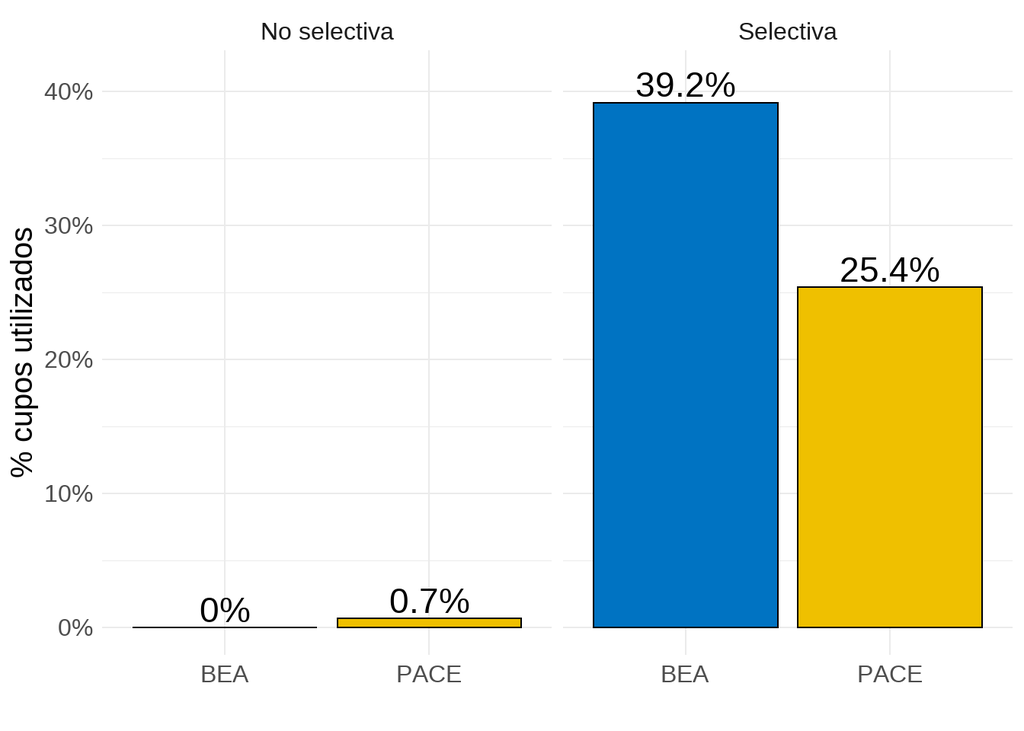

**Figura 15**. El % se calcula con $\frac{N°~cupos~completos ~BEA~}{N°~cupos~ofertados~BEA}$ (lo mismo respectivamente con PACE)